# Practical Machine Learning Project

Diego Andrés Arias

8/30/2020

## Background

Using devices such as Jawbone Up, Nike FuelBand, and Fitbit it is now possible to collect a large amount of data about personal activity relatively inexpensively. These type of devices are part of the quantified self movement – a group of enthusiasts who take measurements about themselves regularly to improve their health, to find patterns in their behavior, or because they are tech geeks. One thing that people regularly do is quantify how much of a particular activity they do, but they rarely quantify how well they do it.

The data consists of a Training data and a Test data. The goal is predict the manner in which they did the exercise.

## Data Processing

We use the following libraries for this analysis.

```r
library(caret)
library(rpart)
library(rpart.plot)
library(RColorBrewer)
library(rattle)
library(randomForest)
library(corrplot)
library(gbm)
library(readr)
library(tidyr)
```

wa read the data from the .csv archive.

```r
trainData <- read_csv("pml-training.csv")
testfinalData <- read_csv("pml-testing.csv")
```

The dimension of the training data is 19622, 160 and the testing data is 20, 160. There are 19622 observations and 160 variables.

## Datasets for predictions

We going to split the trainData into 70% as train data and 30% as test data.

```r
set.seed(299)
trainIndex <- createDataPartition(trainData$classe, p = 0.7, list = FALSE)
train1Data <- trainData[trainIndex, ]
test1Data <- trainData[-trainIndex, ]
```

Next, we going to remove the variables with aproximately zero variance and columns with missing data.

```r
zeroVar <- nearZeroVar(train1Data)
train1Data <- train1Data[, -zeroVar]
train1Data <- train1Data[, colSums(is.na(train1Data)) == 0]
test1Data <- test1Data[, -zeroVar]
test1Data <- test1Data[, colSums(is.na(test1Data)) == 0]
```

Finally, we will use 59 variables for our model. We compute the correlation plot with the first principal component order.

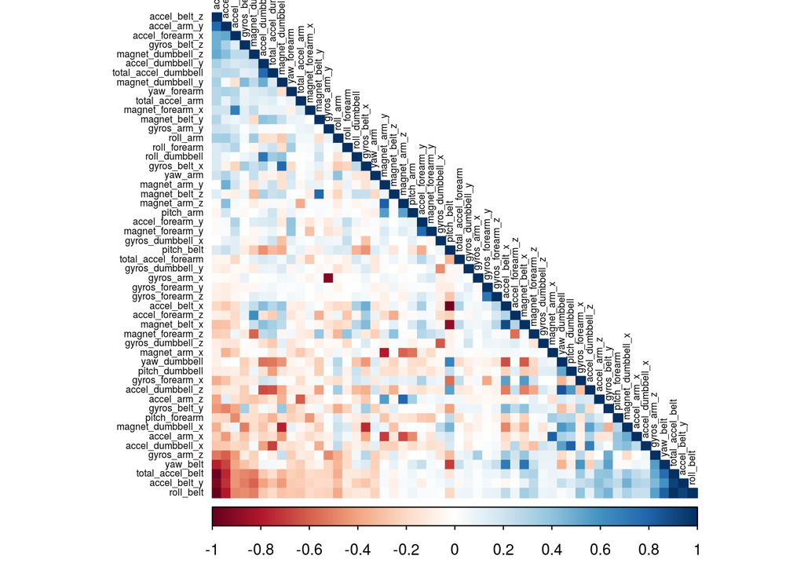

```r
corrTrain <- cor(train1Data[, - c(1:6, 59)])
corrplot(corrTrain, order = "FPC", method = "color", type = "lower", tl.col = "black", tl.cex = 0.5)
```

The dark blue (red) color indicate positive (negative) high correlation. We can identify the variables with high correlation, and remove the high correlate variable from the model as follow

```r
highCorrelation <- findCorrelation(corrTrain, cutoff = 0.8)
train1Data <- train1Data[, - highCorrelation]
test1Data <- test1Data[, - highCorrelation]
```

## Models

We will use two models for this project: random forest and Generalized Boosted Model

### Random forest

First, determine de model

```r
controlRF <- trainControl(method = "cv", number = 2, verboseIter = FALSE)
modelRF <- train(classe ~ ., data = train1Data, method = "rf", trControl = controlRF)
modelRF$finalModel
```

```
##
## Call:
##  randomForest(x = x, y = y, mtry = param$mtry)
##                Type of random forest: classification
##                      Number of trees: 500
## No. of variables tried at each split: 34
##
##         OOB estimate of  error rate: 0.07%
## Confusion matrix:
##      A    B    C    D    E  class.error
## A 3906    0    0    0    0 0.0000000000
## B    2 2656    0    0    0 0.0007524454
## C    0    3 2392    1    0 0.0016694491
## D    0    0    2 2249    1 0.0013321492
## E    0    0    0    0 2525 0.0000000000
```

We test the model using the testing data to obtain Accuracy

```r
predictionRF <- predict(modelRF, newdata = test1Data)
confusion <- confusionMatrix(predictionRF, factor(test1Data$classe))
confusion
```

```
## Confusion Matrix and Statistics
##
##           Reference
## Prediction    A    B    C    D    E
##          A 1674    0    0    0    0
##          B    0 1139    0    0    0
##          C    0    0 1026    0    0
##          D    0    0    0  962    0
##          E    0    0    0    2 1082
##
## Overall Statistics
##
##                Accuracy : 0.9997
##                  95% CI : (0.9988, 1)
##     No Information Rate : 0.2845
##     P-Value [Acc > NIR] : < 2.2e-16
##
##                   Kappa : 0.9996
##
##  Mcnemar's Test P-Value : NA
##
## Statistics by Class:
##
##                      Class: A Class: B Class: C Class: D Class: E
## Sensitivity            1.0000   1.0000   1.0000   0.9979   1.0000
## Specificity            1.0000   1.0000   1.0000   1.0000   0.9996
## Pos Pred Value         1.0000   1.0000   1.0000   1.0000   0.9982
## Neg Pred Value         1.0000   1.0000   1.0000   0.9996   1.0000
## Prevalence             0.2845   0.1935   0.1743   0.1638   0.1839
## Detection Rate         0.2845   0.1935   0.1743   0.1635   0.1839
## Detection Prevalence   0.2845   0.1935   0.1743   0.1635   0.1842
## Balanced Accuracy      1.0000   1.0000   1.0000   0.9990   0.9998
```

The accuracy of the random forest models is near to 1, is to high may be for overfitting.

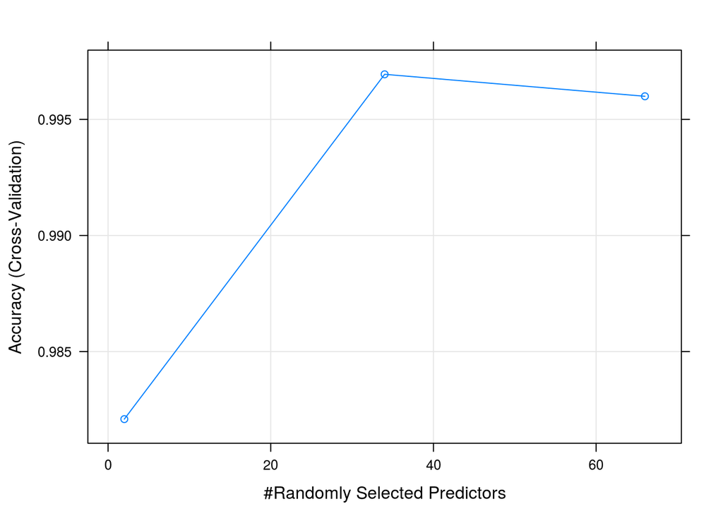

```r
plot(modelRF)
```

## Generalized Boosted Regression Model

```r
set.seed(345)
controlGBM <- trainControl(method = "repeatedcv", number = 5, repeats = 1)
modGBM  <- train(classe ~ ., data=train1Data, method = "gbm", trControl = controlGBM, verbose = FALSE)
modGBM$finalModel
```

```
## A gradient boosted model with multinomial loss function.
## 150 iterations were performed.
## There were 66 predictors of which 63 had non-zero influence.
```

```r
print(modGBM)
```

```
## Stochastic Gradient Boosting
##
## 13737 samples
##    48 predictor
##     5 classes: 'A', 'B', 'C', 'D', 'E'
##
## No pre-processing
## Resampling: Cross-Validated (5 fold, repeated 1 times)
## Summary of sample sizes: 10989, 10989, 10990, 10991, 10989
## Resampling results across tuning parameters:
##
##   interaction.depth  n.trees  Accuracy   Kappa
##   1                   50      0.8324221  0.7870347
##   1                  100      0.8903696  0.8610270
##   1                  150      0.9180317  0.8961541
##   2                   50      0.9515175  0.9385999
##   2                  100      0.9859501  0.9822260
##   2                  150      0.9919195  0.9897790
##   3                   50      0.9815823  0.9766958
##   3                  100      0.9928660  0.9909766
##   3                  150      0.9958507  0.9947517
##
## Tuning parameter 'shrinkage' was held constant at a value of 0.1
##
## Tuning parameter 'n.minobsinnode' was held constant at a value of 10
## Accuracy was used to select the optimal model using the largest value.
## The final values used for the model were n.trees = 150, interaction.depth =
##  3, shrinkage = 0.1 and n.minobsinnode = 10.
```

We predict the testing data with the GBM model

```r
predictionGBM <- predict(modGBM, newdata=test1Data)
confusionGBM <- confusionMatrix(predictionGBM, factor(test1Data$classe))
confusionGBM
```

```
## Confusion Matrix and Statistics
##
##           Reference
## Prediction    A    B    C    D    E
##          A 1674    2    0    0    0
##          B    0 1135    1    0    0
##          C    0    2 1016    3    0
##          D    0    0    9  959    2
##          E    0    0    0    2 1080
##
## Overall Statistics
##
##                Accuracy : 0.9964
##                  95% CI : (0.9946, 0.9978)
##     No Information Rate : 0.2845
##     P-Value [Acc > NIR] : < 2.2e-16
##
##                   Kappa : 0.9955
##
##  Mcnemar's Test P-Value : NA
##
## Statistics by Class:
##
##                      Class: A Class: B Class: C Class: D Class: E
## Sensitivity            1.0000   0.9965   0.9903   0.9948   0.9982
## Specificity            0.9995   0.9998   0.9990   0.9978   0.9996
## Pos Pred Value         0.9988   0.9991   0.9951   0.9887   0.9982
## Neg Pred Value         1.0000   0.9992   0.9979   0.9990   0.9996
## Prevalence             0.2845   0.1935   0.1743   0.1638   0.1839
## Detection Rate         0.2845   0.1929   0.1726   0.1630   0.1835
## Detection Prevalence   0.2848   0.1930   0.1735   0.1648   0.1839
## Balanced Accuracy      0.9998   0.9981   0.9946   0.9963   0.9989
```

## Generalized Boosted Regression Model to validation data

We going to use the Generalized Boosted regression for predict the validation data.

```r
finalResults <- predict(modGBM, newdata = testfinalData)
finalResults
```

```
##  [1] B A B A A E D B A A B C B A E E A B B B
## Levels: A B C D E
```